## 1.1 棒グラフの基本

棒グラフを作成するには，「

[figure not shown]

棒グラフ」を選択します（[@fig-plots-barplot-menu]）。

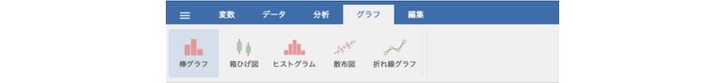

図1.1: 棒グラフ

すると，次のような設定パネルが表示されます（[@fig-plots-barplot-setting]）。

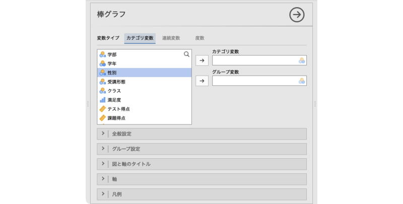

図1.2: 棒グラフの設定パネル

「棒グラフ」というタイトルの下には「変数タイプ」という項目があり，次の3つのタイプが選択できます。

- カテゴリ変数 名義尺度変数の度数を図示したい場合に使用します。
- 連続変数 数値変数の平均値を図示したい場合に使用します。
- 度数 集計済みデータで度数を図示したい場合に使用します。

ここでどのタイプを選択するかによって，パネルに表示される設定項目が異なります。それぞれのタイプ別に基本的な部分を見ていきましょう。

### 1.1.1 カテゴリ変数

変数タイプが「カテゴリ変数」の場合，次のような設定パネルになります（[@fig-plots-barplot-categorical]）。

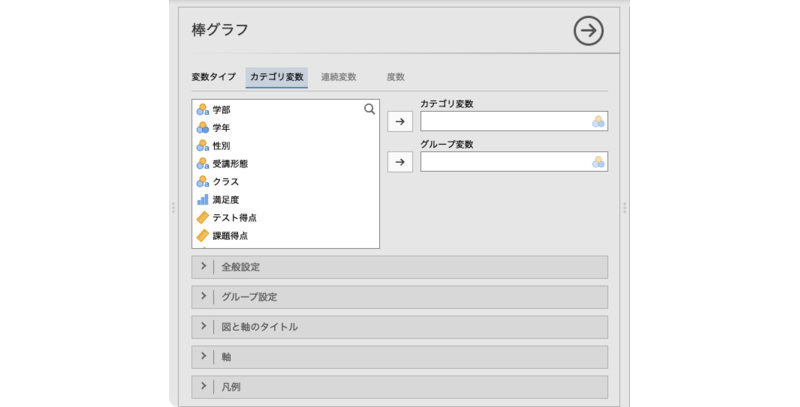

図1.3: 「カテゴリ変数」の設定パネル

- カテゴリ変数 図示したいカテゴリ変数を指定します。
- グループ変数 グループ別に図示したい場合に使用します。

[figure not shown]

- | 全般設定 図の向きや棒の幅など，棒グラフの全体的な見た目の設定を行います。

[figure not shown]

- | グループ設定 作図の際のグループ変数の扱い方を設定します。

[figure not shown]

- | 図と軸のタイトル 図のタイトルやサブタイトル，軸のタイトル，キャプションの表示方法を設定します。

[figure not shown]

- | 軸 軸の範囲や軸ラベルの向きなどを設定します。

[figure not shown]

- | 凡例 凡例（レジェンド）の表示方法や位置を設定します。

一例として，何学部の学生が何人いるのかを図示したいとします。その場合，所属学部は名義尺度データでカテゴリ変数ですので，「変数タイプ」は「カテゴリ変数」が適切です。そして，「カテゴリ変数」のところに「学部」変数を移動すると，各学部の人数（度数）の棒グラフが作成されます（[@fig-plots-barplot-categorical-freq]）。

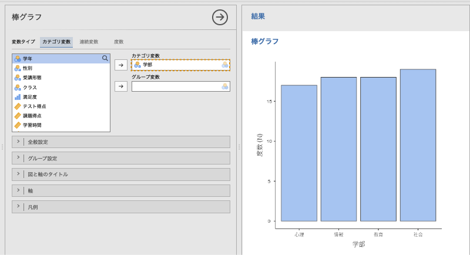

図1.4: 「カテゴリ変数」の棒グラフ

今度は，各学部の人数を受講形態別に図示してみましょう。そして，「グループ変数」に「受講形態」変数を移動すると，各学部の人数（度数）の棒グラフが受講形態別に作成されます（[@fig-plots-barplot-categorical-freq-grouped]）。

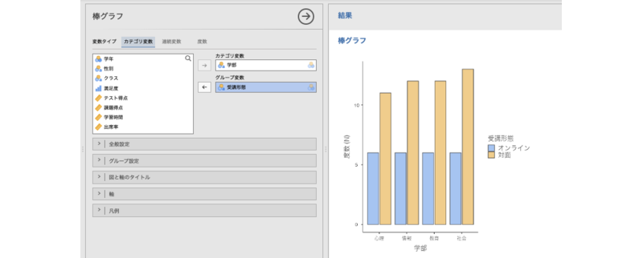

図1.5: 「カテゴリ変数」の棒グラフ（グループ別）

#### 1.1.1.1 全般設定

設定パネルの

[figure not shown]

| 全般設定には，次の項目が含まれています。

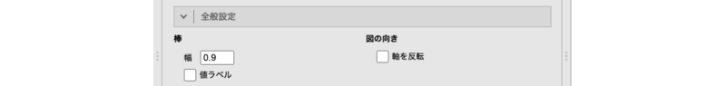

図1.6: 全般設定

- **棒**
  - 幅 棒グラフの棒の幅を設定します（初期値0.9）。
  - 値ラベル 棒の先に度数を表示させたい場合にはチェックを入れます。
- **図の向き**
  - 軸を反転 縦軸と横軸を反転させたい場合にはチェックを入れます。

#### 1.1.1.2 グループ設定

[figure not shown]

| グループ設定には，次の項目が含まれています。

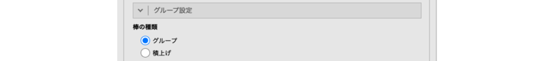

図1.7: グループ設定

- **棒**
  - グループ 棒グラフをグループ別に横並びに表示します。
  - 積上げ 各グループの値を積み上げて表示します。

[figure not shown]

図1.8: グループ設定

#### 1.1.1.3 図と軸のタイトル

[figure not shown]

| 図と軸のタイトルには，次の5つのタブが含まれています。

- 図のタイトル タイトルの内容やサイズ，書体，揃え位置を設定します。
- 図のサブタイトル サブタイトルの内容やサイズ，書体，揃え位置を設定します。
- 図のキャプション キャプションの内容やサイズ，書体，揃え位置を設定します。
- X軸タイトル X軸のタイトルやサイズ，書体，揃え位置を設定します。
- Y軸タイトル Y軸のタイトルやサイズ，書体，揃え位置を設定します。

各タイトルは，図の次の部分を指します（[@fig-plots-barplot-cetegorical-plot-titles]）。

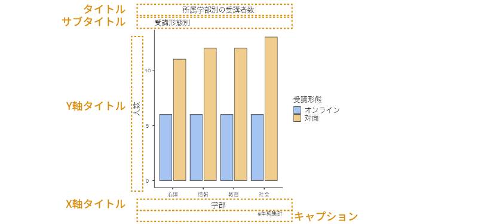

図1.9: タイトル設定

#### 1.1.1.4 軸

[figure not shown]

| 軸には，次の項目が含まれています。

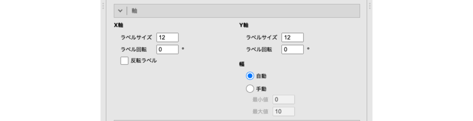

図1.10: 軸

#### 1.1.1.5 凡例

[figure not shown]

| 凡例には，次の項目が含まれています。

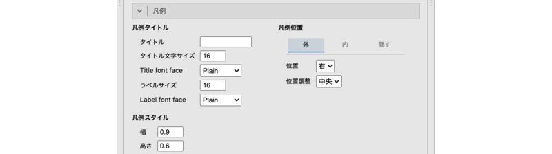

### 1.1.2 連続変数

連続変数の場合，次のような設定パネルになります（[@fig-plots-barplot-continuous]）。

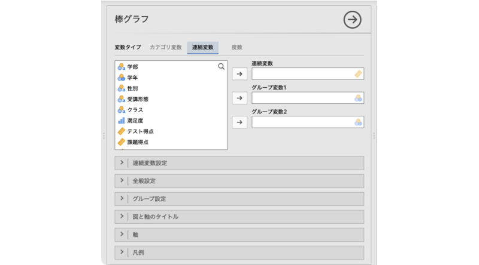

図1.12: 「連続変数」の設定パネル

- 連続変数 平均値を図示したい値が含まれている連続変数を指定します。
- グループ変数1 グループ別に集計した値を図示したい場合に使用します。
- グループ変数2 複数種類のグループを組み合わせて図示したい場合に使用します。

[figure not shown]

- | 連続変数設定 グラフに表示する誤差線を設定します。

[figure not shown]

- | 全般設定 図の向きや棒の幅など，棒グラフの全体的な見た目の設定を行います。

[figure not shown]

- | グループ設定 作図の際のグループ変数の扱い方を設定します。

[figure not shown]

- | 図と軸のタイトル 図のタイトルやサブタイトル，軸のタイトル，キャプションの表示方法を設定します。

[figure not shown]

- | 軸 軸の範囲や軸ラベルの向きなどを設定します。

[figure not shown]

- | 凡例 凡例（レジェンド）の表示方法や位置を設定します。

### 1.1.3 度数

度数の場合，次のような設定パネルになります（[@fig-plots-barplot-frequency]）。

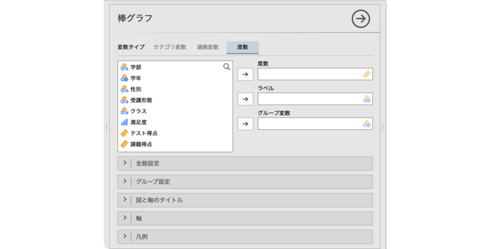

図1.13: 「度数」の設定パネル

- 度数 度数が含まれている変数を指定します。
- ラベル グラフのラベルとして使用する変数を指定します。
- グループ変数 グループ別に図示したい場合に使用します。

[figure not shown]

- | 全般設定 図の向きや棒の幅など，棒グラフの全体的な見た目の設定を行います。

[figure not shown]

- | グループ設定 作図の際のグループ変数の扱い方を設定します。

[figure not shown]

- | 図と軸のタイトル 図のタイトルやサブタイトル，軸のタイトル，キャプションの表示方法を設定します。

[figure not shown]

- | 軸 軸の範囲や軸ラベルの向きなどを設定します。

[figure not shown]

- | 凡例 凡例（レジェンド）の表示方法や位置を設定します。